# Análise - Marcelo Zorovich

Rafael Magalhães

06 de fevereiro, 2020

## Correlograma

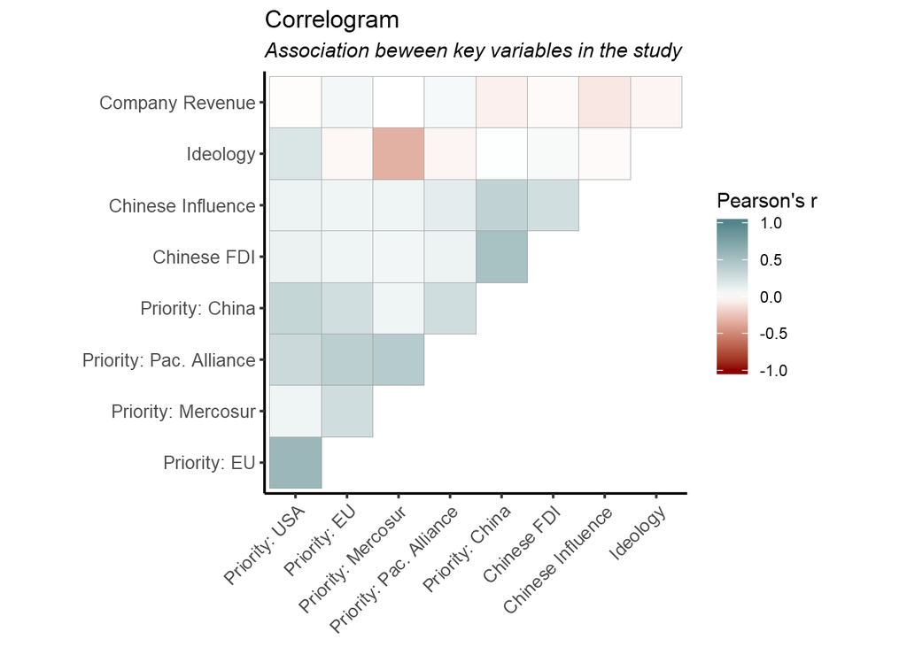

## Modelos de Regressão

### Variável Dependente: FDI

#### Modelos lineares

##### Gráfico

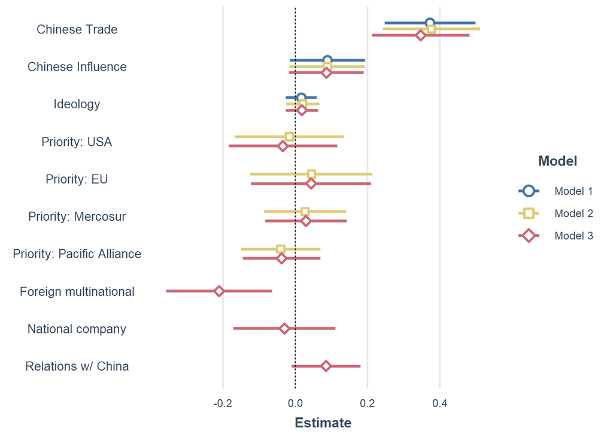

##### Tabela

```r
stargazer(f1,
          f2,
          f3,
          covariate.labels = c("Chinese Trade",
                               "Chinese Influence",
                               "Ideology",
                               "Priority: USA",
                               "Priority: EU",
                               "Priority: Mercosur",
                               "Priority: Pacific Alliance",
                               "Foreign multinational",
                               "National company",
                               "Relations w/ China"),
          dep.var.labels = "Chinese FDI",
          model.numbers = FALSE,
          type = "html")
```

|  | *Dependent variable:* |  |  |
| --- | --- | --- | --- |
|  | Chinese FDI |  |  |
| Chinese Trade | 0.373*** | 0.377*** | 0.347*** |
|  | (0.064) | (0.068) | (0.069) |
| Chinese Influence | 0.089* | 0.089* | 0.087* |
|  | (0.053) | (0.053) | (0.053) |
| Ideology | 0.010 | 0.012 | 0.011 |
|  | (0.013) | (0.013) | (0.013) |
| Priority: USA |  | -0.016 | -0.034 |
|  |  | (0.077) | (0.076) |
| Priority: EU |  | 0.045 | 0.044 |
|  |  | (0.086) | (0.084) |
| Priority: Mercosur |  | 0.027 | 0.030 |
|  |  | (0.058) | (0.057) |
| Priority: Pacific Alliance |  | -0.040 | -0.038 |
|  |  | (0.056) | (0.055) |
| Foreign multinational |  |  | -0.210*** |
|  |  |  | (0.074) |
| National company |  |  | -0.030 |
|  |  |  | (0.072) |
| Relations w/ China |  |  | 0.085* |
|  |  |  | (0.049) |
| Constant | 0.342*** | 0.305** | 0.387*** |
|  | (0.095) | (0.118) | (0.136) |
| Observations | 312 | 312 | 312 |
| R<sup>2</sup> | 0.140 | 0.142 | 0.184 |
| Adjusted R<sup>2</sup> | 0.132 | 0.122 | 0.157 |
| Residual Std. Error | 0.383 (df = 308) | 0.385 (df = 304) | 0.378 (df = 301) |
| F Statistic | 16.724*** (df = 3; 308) | 7.200*** (df = 7; 304) | 6.809*** (df = 10; 301) |
| *Note:* | p<0.1; p<0.05; p<0.01 |  |  |

#### Modelos Logit

##### Gráfico

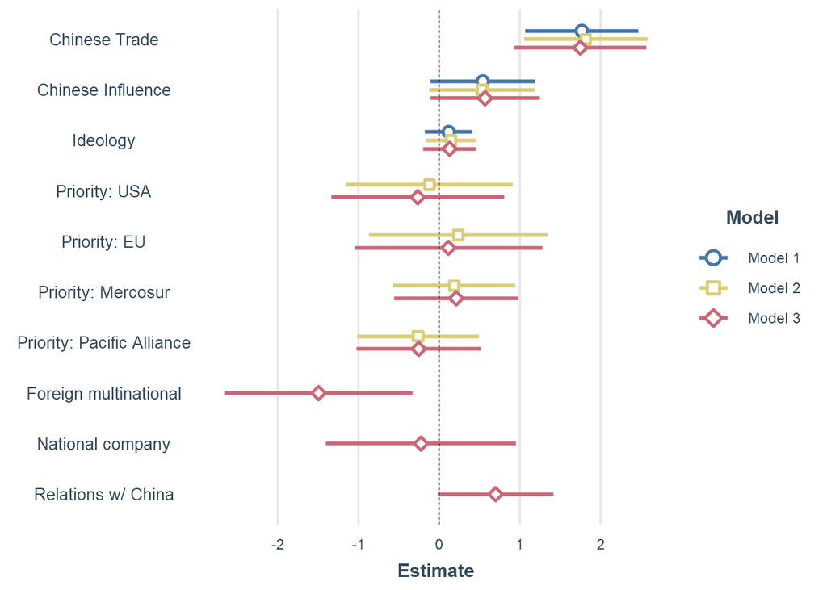

##### Tabela

```r
stargazer(fl1,
          fl2,
          fl3,
          covariate.labels = c("Chinese Trade",
                               "Chinese Influence",
                               "Ideology",
                               "Priority: USA",
                               "Priority: EU",
                               "Priority: Mercosur",
                               "Priority: Pacific Alliance",
                               "Foreign multinational",
                               "National company",
                               "Relations w/ China"),
          dep.var.labels = "Chinese FDI",
          model.numbers = FALSE,
          type = "html")
```

|  | *Dependent variable:* |  |  |
| --- | --- | --- | --- |
|  | Chinese FDI |  |  |
| Chinese Trade | 1.767*** | 1.815*** | 1.749*** |
|  | (0.357) | (0.391) | (0.418) |
| Chinese Influence | 0.541 | 0.533 | 0.569* |
|  | (0.331) | (0.333) | (0.345) |
| Ideology | 0.069 | 0.085 | 0.075 |
|  | (0.086) | (0.092) | (0.096) |
| Priority: USA |  | -0.118 | -0.266 |
|  |  | (0.527) | (0.547) |
| Priority: EU |  | 0.240 | 0.115 |
|  |  | (0.567) | (0.592) |
| Priority: Mercosur |  | 0.184 | 0.212 |
|  |  | (0.388) | (0.393) |
| Priority: Pacific Alliance |  | -0.260 | -0.253 |
|  |  | (0.384) | (0.393) |
| Foreign multinational |  |  | -1.493** |
|  |  |  | (0.595) |
| National company |  |  | -0.226 |
|  |  |  | (0.601) |
| Relations w/ China |  |  | 0.700* |
|  |  |  | (0.364) |
| Constant | -0.886 | -1.089 | -0.497 |
|  | (0.607) | (0.750) | (0.973) |
| Observations | 312 | 312 | 312 |
| Log Likelihood | -143.578 | -143.240 | -135.489 |
| Akaike Inf. Crit. | 295.155 | 302.480 | 292.978 |
| *Note:* | p<0.1; p<0.05; p<0.01 |  |  |

### Variável Dependente: Trade

#### Modelos lineares

##### Gráfico

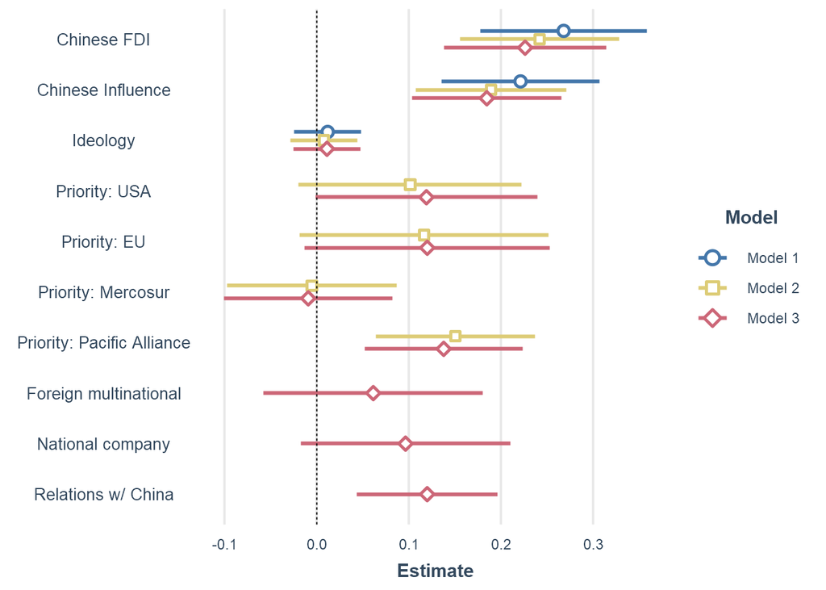

##### Tabela

```r
stargazer(m1,
          m2,
          m3,
          covariate.labels = c("Chinese FDI",
                               "Chinese Influence",
                               "Ideology",
                               "Priority: USA",
                               "Priority: EU",
                               "Priority: Mercosur",
                               "Priority: Pacific Alliance",
                               "Foreign multinational",
                               "National company",
                               "Relations w/ China"),
          dep.var.labels = "Trade Priority w/ China",
          model.numbers = FALSE,
          type = "html")
```

|  | *Dependent variable:* |  |  |
| --- | --- | --- | --- |
|  | Trade Priority w/ China |  |  |
| Chinese FDI | 0.268*** | 0.242*** | 0.226*** |
|  | (0.046) | (0.044) | (0.045) |
| Chinese Influence | 0.221*** | 0.189*** | 0.185*** |
|  | (0.043) | (0.042) | (0.041) |
| Ideology | 0.007 | 0.005 | 0.006 |
|  | (0.011) | (0.011) | (0.011) |
| Priority: USA |  | 0.101 | 0.119* |
|  |  | (0.062) | (0.061) |
| Priority: EU |  | 0.117* | 0.120* |
|  |  | (0.069) | (0.068) |
| Priority: Mercosur |  | -0.005 | -0.009 |
|  |  | (0.047) | (0.046) |
| Priority: Pacific Alliance |  | 0.151*** | 0.138*** |
|  |  | (0.044) | (0.043) |
| Foreign multinational |  |  | 0.061 |
|  |  |  | (0.061) |
| National company |  |  | 0.096* |
|  |  |  | (0.058) |
| Relations w/ China |  |  | 0.120*** |
|  |  |  | (0.039) |
| Constant | 0.427*** | 0.193** | 0.045 |
|  | (0.078) | (0.095) | (0.111) |
| Observations | 312 | 312 | 312 |
| R<sup>2</sup> | 0.199 | 0.287 | 0.312 |
| Adjusted R<sup>2</sup> | 0.192 | 0.270 | 0.289 |
| Residual Std. Error | 0.325 (df = 308) | 0.309 (df = 304) | 0.305 (df = 301) |
| F Statistic | 25.557*** (df = 3; 308) | 17.473*** (df = 7; 304) | 13.640*** (df = 10; 301) |
| *Note:* | p<0.1; p<0.05; p<0.01 |  |  |

#### Modelos Logit

##### Gráfico

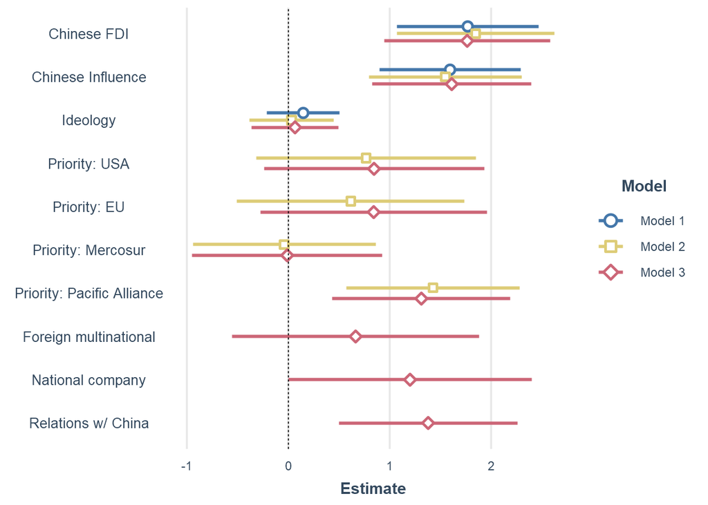

##### Tabela

```r
stargazer(l1,
          l2,
          l3,
          covariate.labels = c("Chinese FDI",
                               "Chinese Influence",
                               "Ideology",
                               "Priority: USA",
                               "Priority: EU",
                               "Priority: Mercosur",
                               "Priority: Pacific Alliance",
                               "Foreign multinational",
                               "National company",
                               "Relations w/ China"),
          dep.var.labels = "Trade Priority w/ China",
          model.numbers = FALSE,
          type = "html")
```

|  | *Dependent variable:* |  |  |
| --- | --- | --- | --- |
|  | Trade Priority w/ China |  |  |
| Chinese FDI | 1.769*** | 1.848*** | 1.764*** |
|  | (0.357) | (0.396) | (0.418) |
| Chinese Influence | 1.595*** | 1.550*** | 1.611*** |
|  | (0.355) | (0.384) | (0.400) |
| Ideology | 0.085 | 0.019 | 0.038 |
|  | (0.105) | (0.122) | (0.126) |
| Priority: USA |  | 0.766 | 0.845 |
|  |  | (0.552) | (0.554) |
| Priority: EU |  | 0.616 | 0.842 |
|  |  | (0.572) | (0.569) |
| Priority: Mercosur |  | -0.040 | -0.011 |
|  |  | (0.460) | (0.478) |
| Priority: Pacific Alliance |  | 1.426*** | 1.312*** |
|  |  | (0.436) | (0.448) |
| Foreign multinational |  |  | 0.664 |
|  |  |  | (0.621) |
| National company |  |  | 1.200* |
|  |  |  | (0.613) |
| Relations w/ China |  |  | 1.379*** |
|  |  |  | (0.448) |
| Constant | -0.987 | -2.522*** | -4.390*** |
|  | (0.706) | (0.967) | (1.232) |
| Observations | 312 | 312 | 312 |
| Log Likelihood | -106.447 | -92.652 | -86.965 |
| Akaike Inf. Crit. | 220.893 | 201.305 | 195.930 |
| *Note:* | p<0.1; p<0.05; p<0.01 |  |  |

## Experimento: metodologia e resultados

Os resultados do experimento são muito animadores do ponto de vista estatístico, e os mais inovadores do ponto de vista do desenho da pesquisa. Os respondentes foram alocados **aleatoriamente** em 3 diferentes grupos, e todos responderam exatamente às mesmas perguntas, com exceção da última.

A última pergunta solicitava ao respondente que se posicionasse a favor ou contra medidas restritivas e imposição de barreiras tarifárias à China. O enunciado, porém, tinha 3 versões diferentes. Ao abrir o questionário, o respondente era sorteado automaticamente para receber um dos seguintes textos:

**Grupo A (controle)**: “No Brasil, há questionamentos quanto a se deveríamos impor limites aos investimentos chineses no país. Neste sentido, com relação a negociações com a China, fomento de acordos comerciais e atração de investimentos diretos estrangeiros no Brasil, qual das alternativas melhor reflete a visão de sua empresa?”

**Grupo B (tratamento positivo)**: “A estratégia internacional “going global” da China e a criação do Fundo Brasil-China de US$ 20 bilhões indicam que uma nova etapa nas relações econômicas Brasil-China foi iniciada. Além de principal parceiro comercial, a China passa a ter uma contribuição relevante na entrada de investimentos diretos estrangeiros no Brasil. Diante deste contexto, qual das alternativas melhor reflete a visão de sua empresa?"

**Grupo C (tratamento negativo)**: “Constata-se que as exportações da América Latina para a China são mais intensivas em gases poluentes do que as exportações para o resto do mundo e que os investimentos externos diretos da China para a região também estão mais concentrados em setores mais intensivos em gases poluentes. Argumenta-se que estas violações do meio ambiente podem diminuir o interesse para negociações, acordos comerciais e de investimentos com reflexo na atração de investimentos diretos estrangeiros por parte da China. Qual das alternativas melhor reflete a visão de sua empresa?”

O primeiro texto tem uma redação neutra, que utilizaremos como *benchmark*. Esse será nosso grupo de controle. O grupo B, por sua vez, introduz informações favoráveis à China, lembrando ao entrevistado a relevância do país para o comércio externo brasileiro. Por fim, o grupo C traz informações negativas sobre a China, mencionando sua má reputação na proteção do meio ambiente. A grande vantagem desse desenho de pesquisa é que conseguimos capturar o efeito preciso da redação da pergunta sobre a predisposição do entrevistado a apoiar barreiras comerciais à China, eliminando relações espúrias que poderiam ser ocasionadas por covariáveis não controladas (ou não observadas).

Os resultados são interessantes. O gráfico abaixo mostra que, entre os respondentes que receberam o texto neutro, 23,9% se declaram favoráveis a medidas protetivas contra a China. Entre aqueles que receberam o tratamento positivo, 19,2% se declaram favoráveis. O tratamento positivo não é estatisticamente diferente do grupo de tratamento (p > 0,05). Um possível motivo para isso é que as informações sobre o comércio brasileiro com a China já sejam conhecidas entre os respondentes. Neste caso, o tratamento positico não estaria trazendo nenhuma informação nova, e não deveríamos esperar diferença significativa entre os grupos A e B.

O tratamento negativo, por sua vez, tem efeito bastante visível. Entre esses respondentes, 42,1% se declaram favoráveis à imposição de barreiras à China, valor considerável quando comparado aos 23,9% no grupo de controle. A diferença entre os grupos A e C é estatisticamente significativa (p = 0,008), de modo que **a pesquisa mostra evidência robusta de que tomadores de decisão mudam sua postura em relação à China quando são lembrados do tratamento que aquele país dispensa ao meio ambiente**. Trata-se de um resultado iluminador não só para a compreensão das dinâmicas globais de investimento, como também para a discussão das possíveis consequências da agenda ambiental do Brasil.

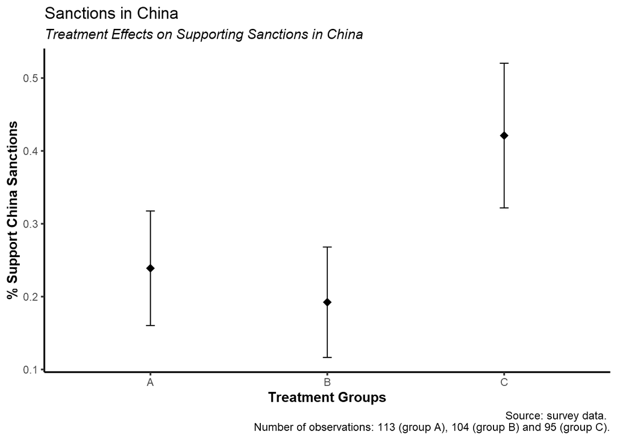

## Perfil dos Respondentes

Os respondentes têm distribuição ideológica com tendências de centro-direita. A amostra é composta por decisores de todas as matizes, e não há variação significativa entre diferentes níveis hierárquicos.

### Ideologia por nível hierárquico

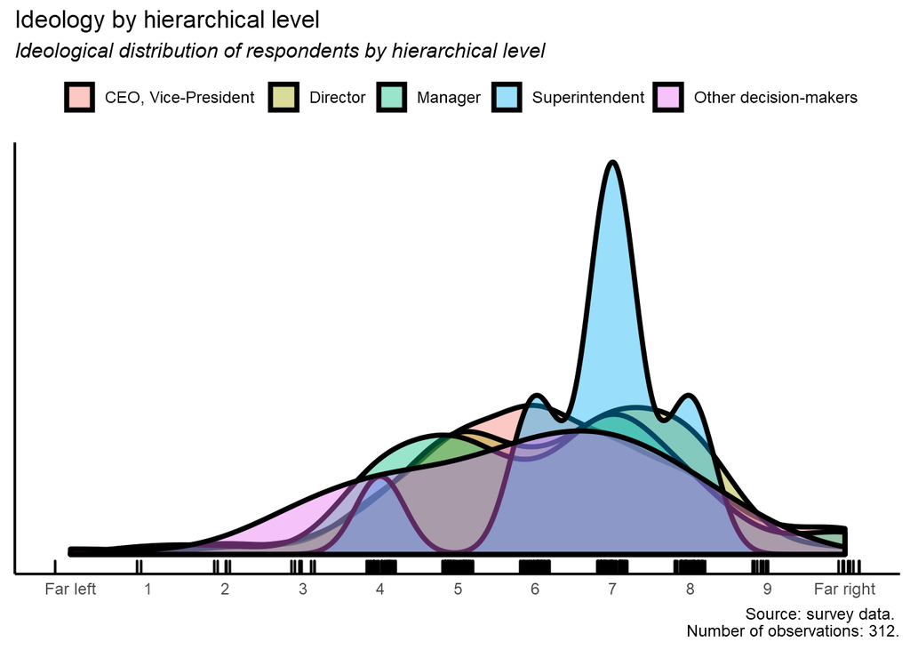

### Distribuição Total

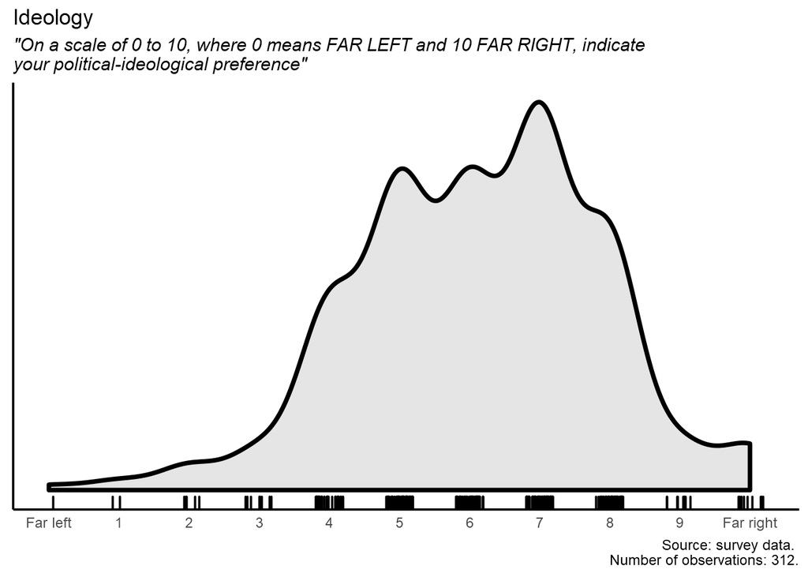

## Relações com a China por tipo de empresa

Entre as empresas representadas na amostra, as nacionais são aquelas que têm menor nível de relacionamento com a China. Multinacionais com operações no Brasil, por sua vez, têm o maior nível de associação com a economia chinesa.

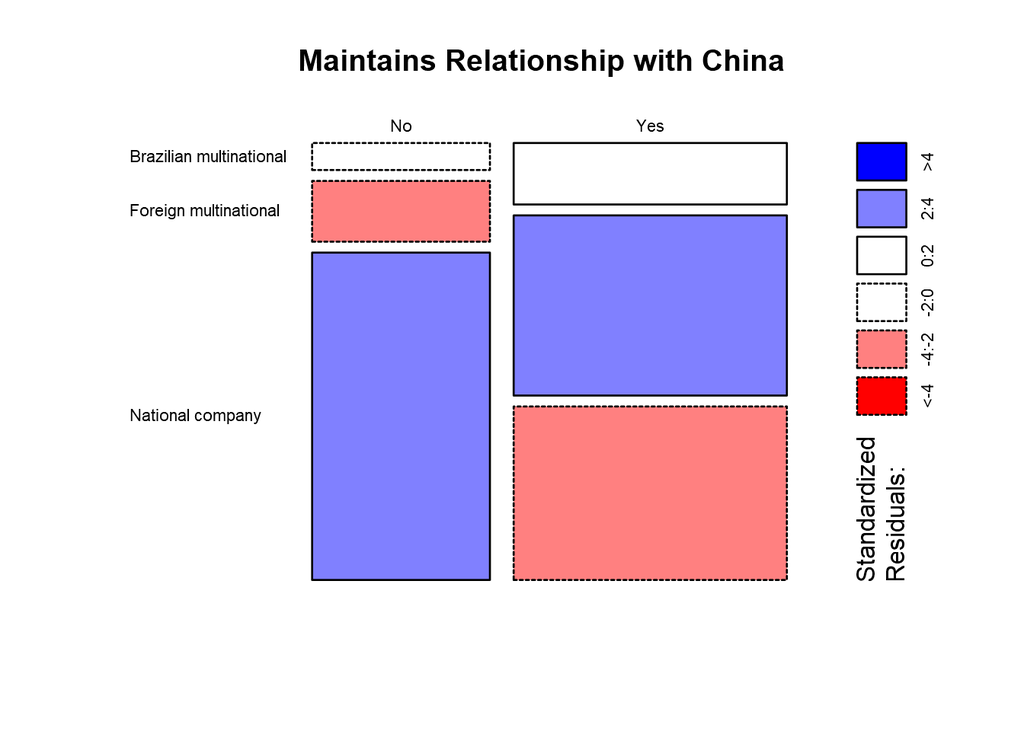

## Prioridades

Clique no país/região desejado para ver o gráfico correspondente.

### China

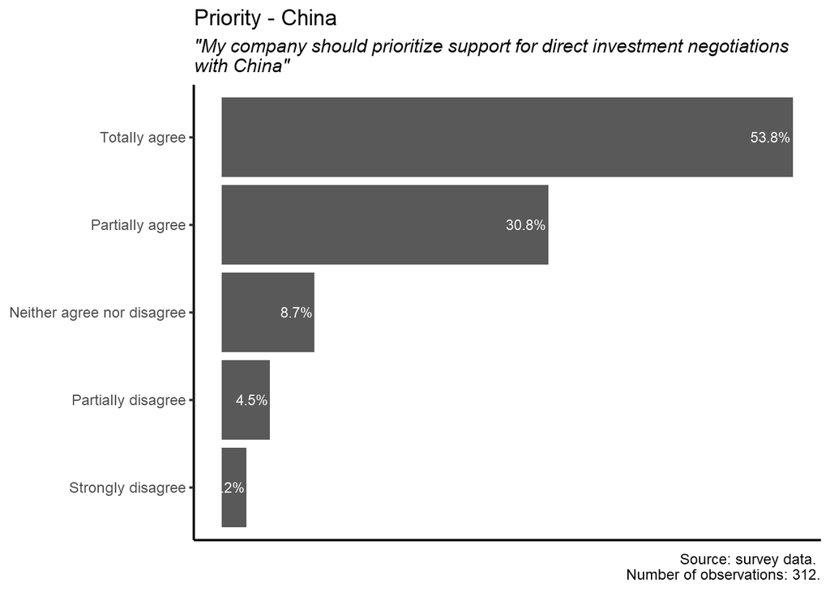

### EUA

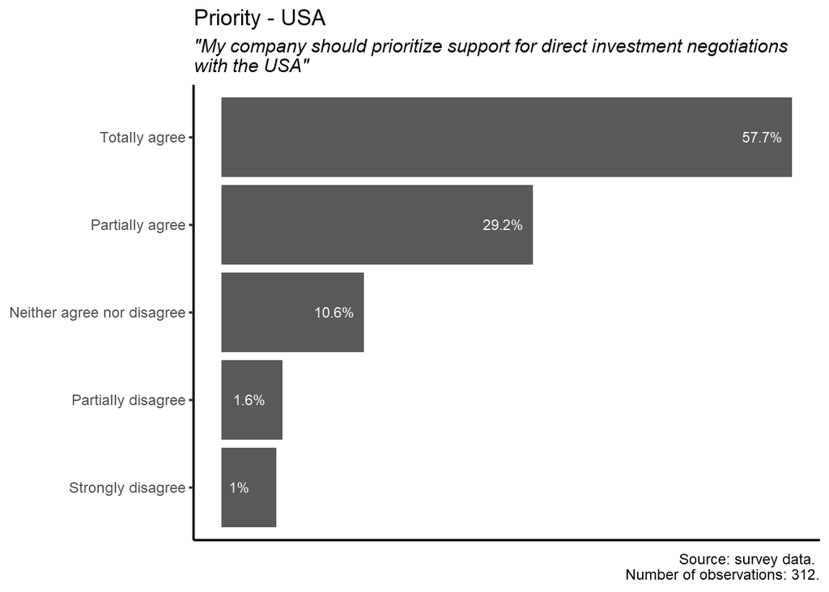

### UE

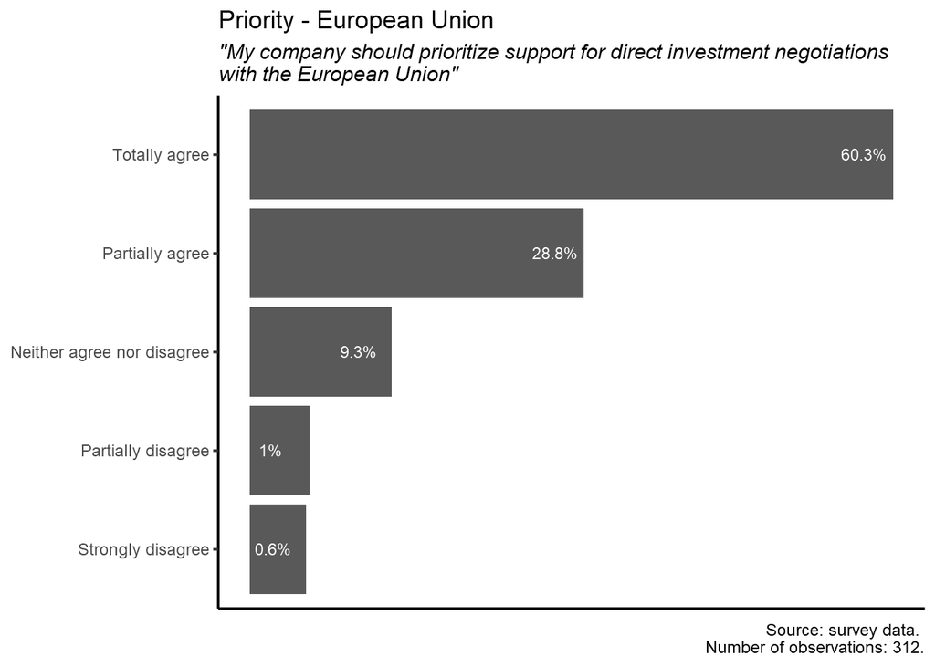

### Mercosul

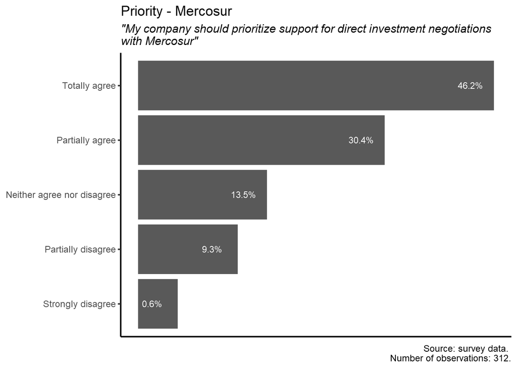

### Aliança do Pacífico

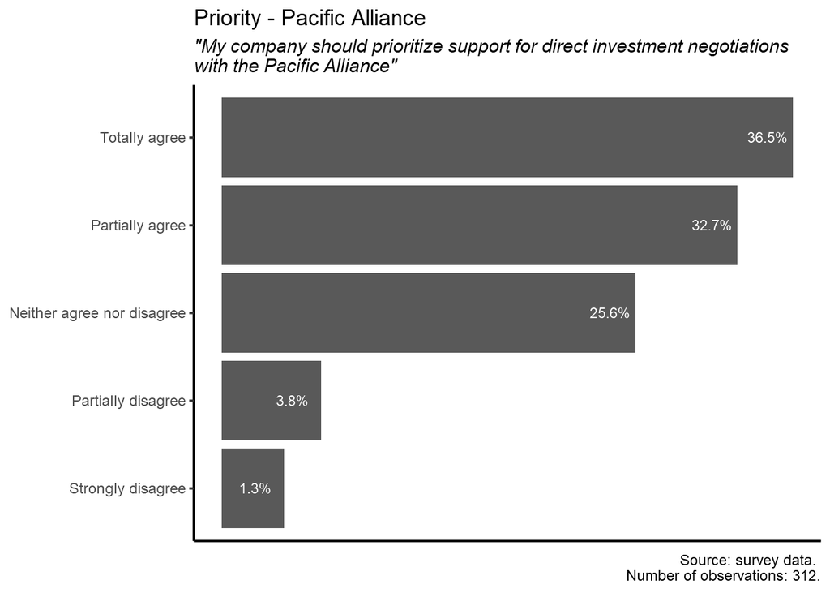

## Atores

Chama a atenção o baixo nível de confiança no sistema político brasileiro, principalmente partidos políticos e o Congresso Nacional. É possível observar um padrão no qual os setores mais bem avaliados do Estado fazem parte do Poder Executivo, seja o nível federal ou os governos dos entes subnacionais.

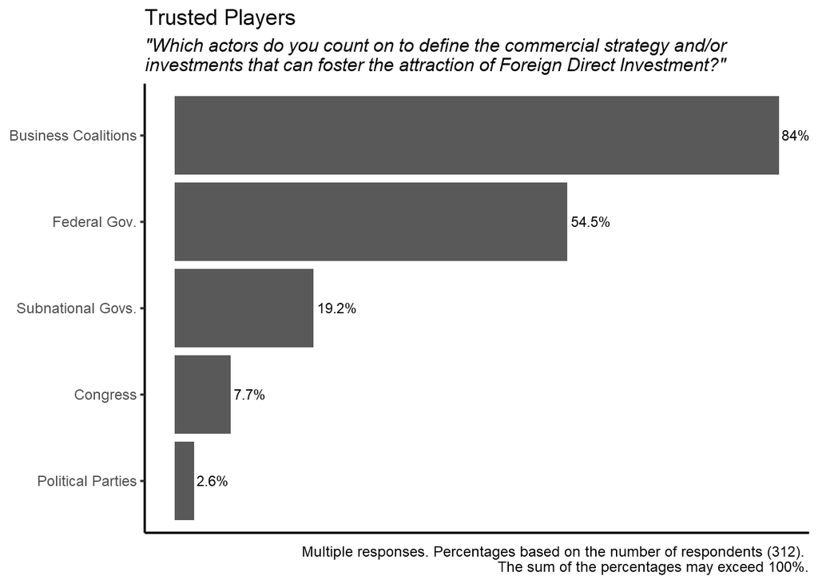

## Investimentos Diretos

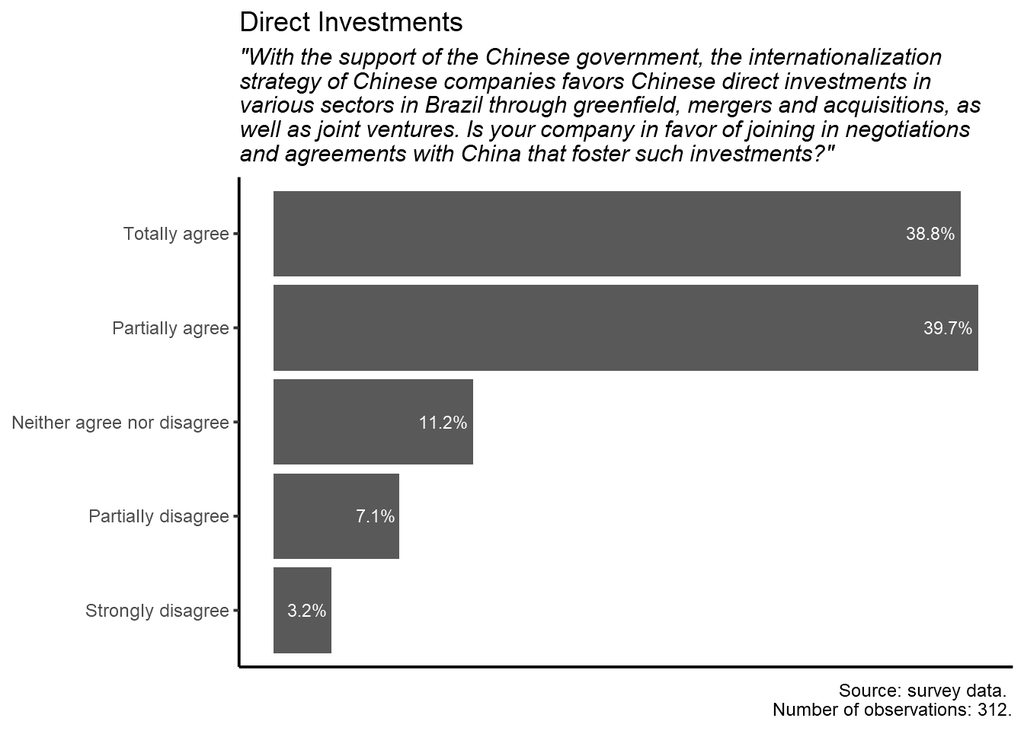

## China vs EUA

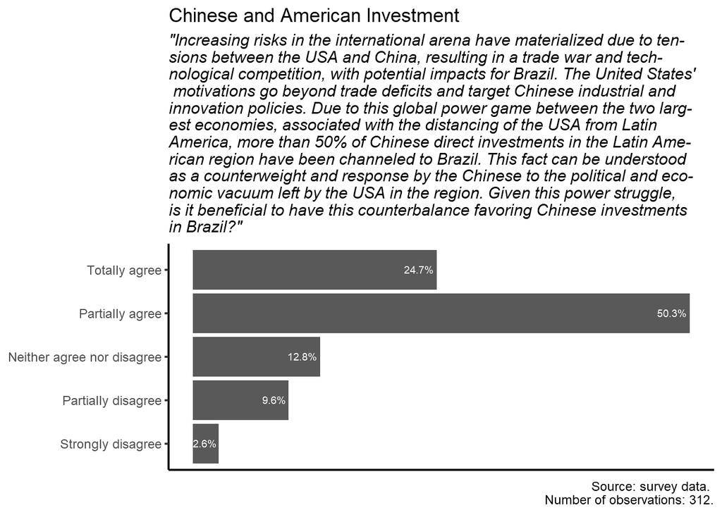

## País de origem das empresas

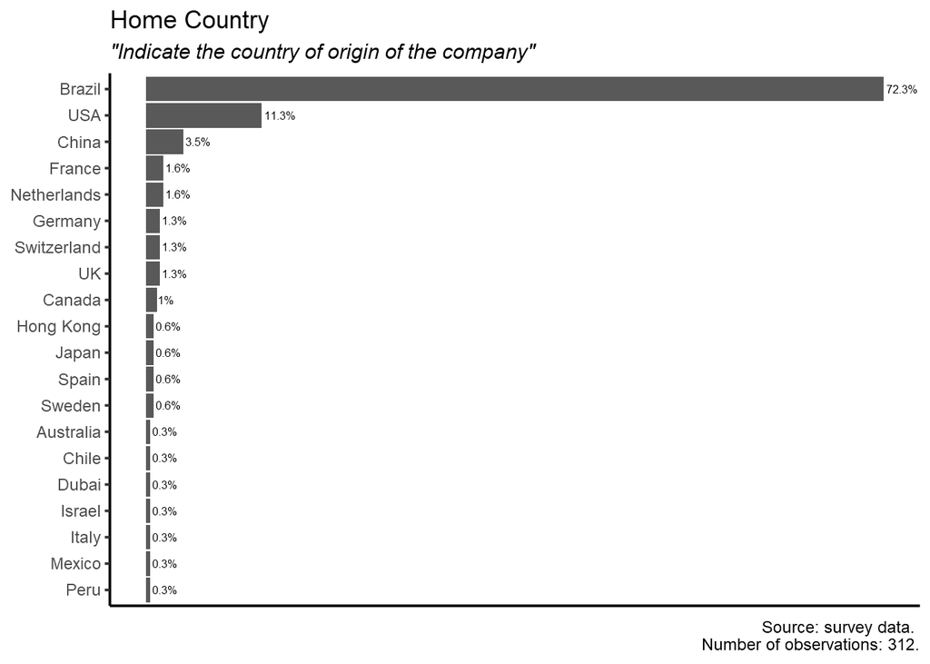

## Nível hierárquico

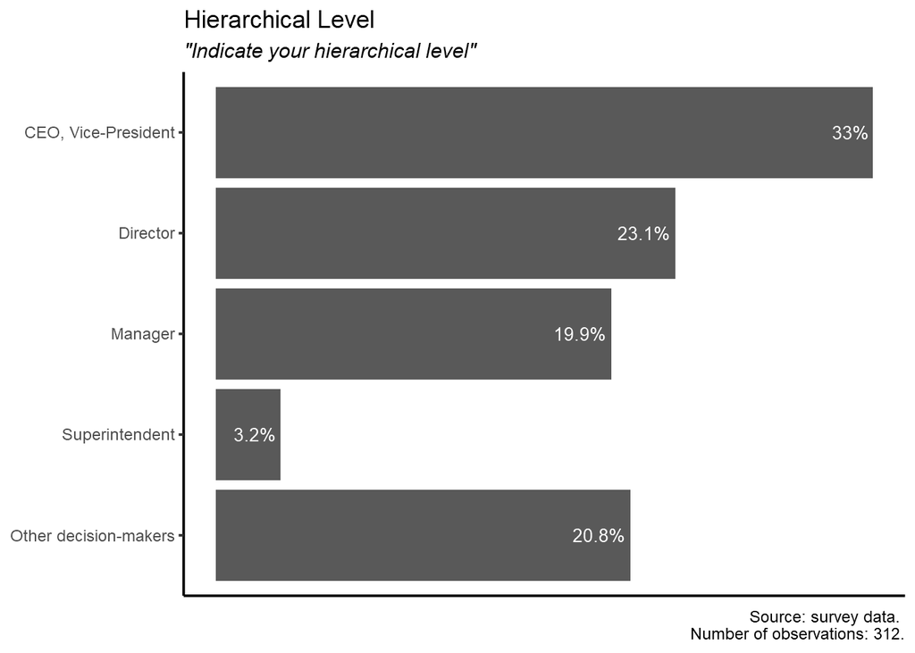

## Setor

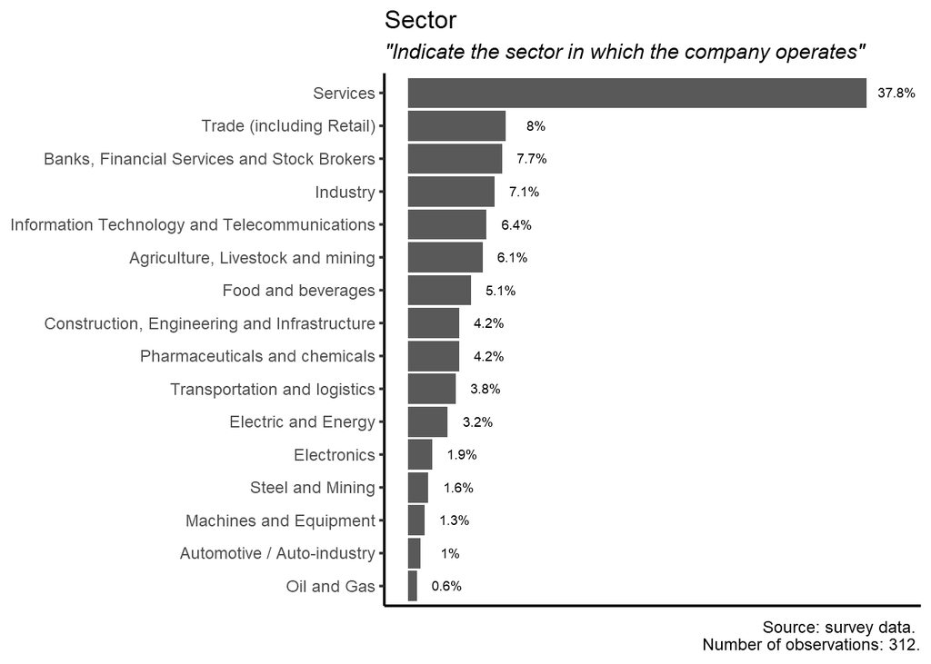

## Tipo de empresa

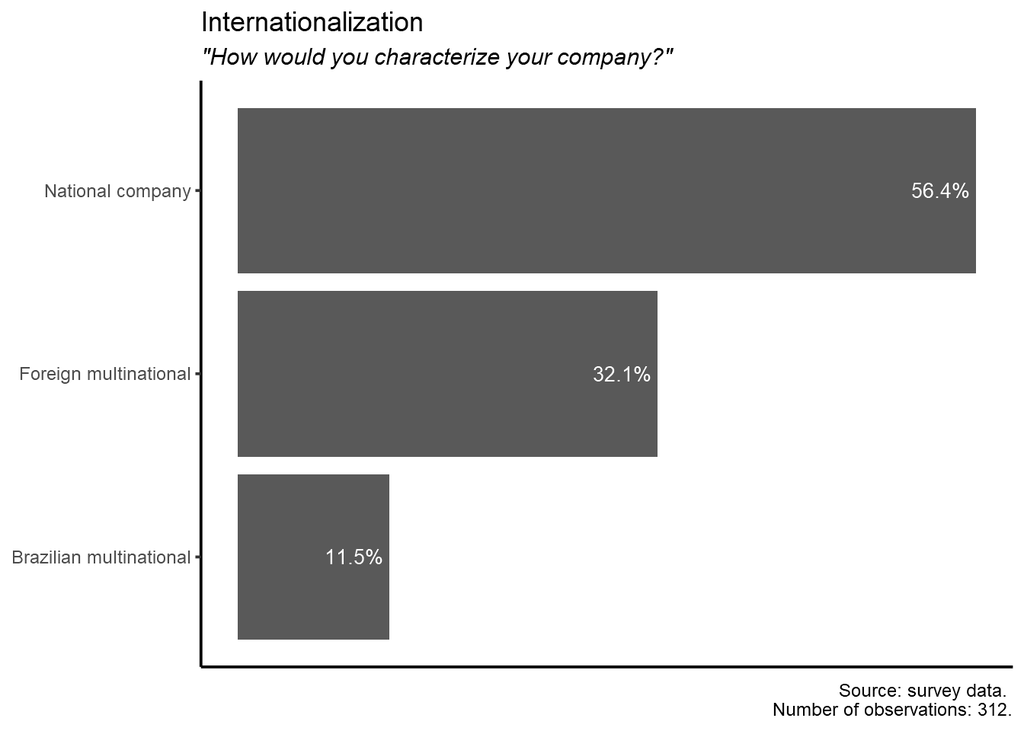

## Receita

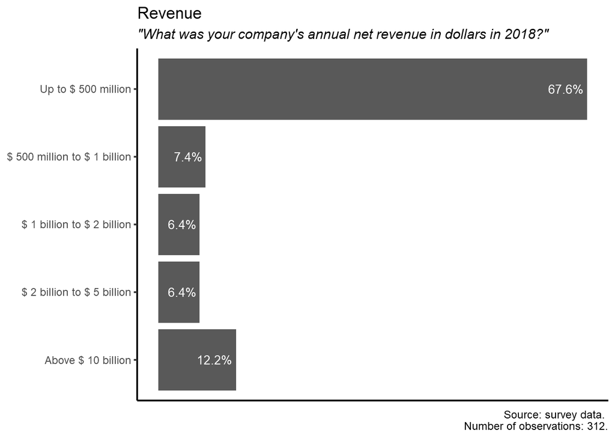

## Relações com a China

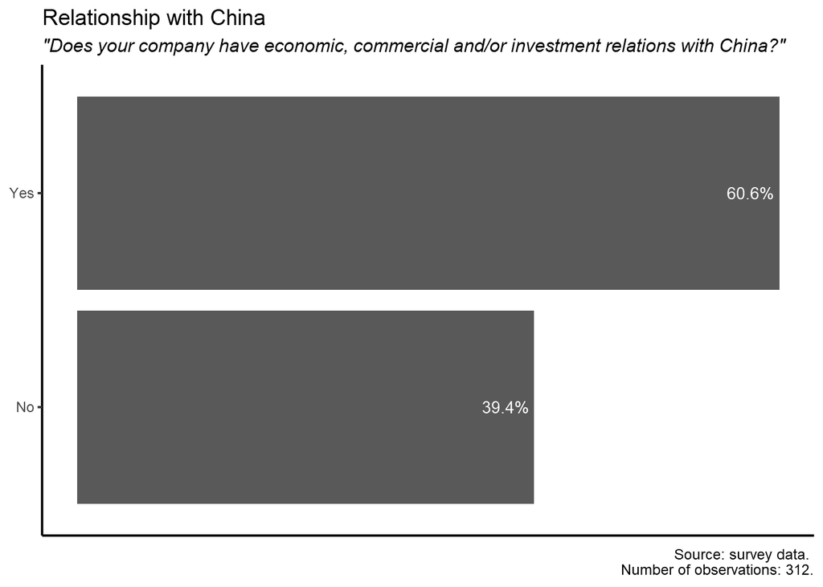